# Exercise 4.2.9 - Bivariate EDA on MEPS data

W. Mangrobang

August 27, 2018

#### Get the data

```r
library(miceadds) #To load Rdata
load.Rdata('/Users/Werlindo/Dropbox/PACP/data/H171.Rdata','meps')

#Take a look
head(meps[,1:10])
```

```
##    DUID PID DUPERSID PANEL FAMID31 FAMID42 FAMID53 FAMID14 FAMIDYR
## 1 40001 101 40001101    18       A       A       A       A       A
## 2 40001 102 40001102    18       A       A       A       A       A
## 3 40001 103 40001103    18       A       A       A       A       A
## 4 40001 104 40001104    18       A       A       A       A       A
## 5 40002 101 40002101    18       A       A       A       A       A
## 6 40004 101 40004101    18       A       A       A       A       A
##   CPSFAMID
## 1        A
## 2        A
## 3        A
## 4        A
## 5        A
## 6        A
```

```r
tail(meps[,1:10])
```

```
##        DUID PID DUPERSID PANEL FAMID31 FAMID42 FAMID53 FAMID14 FAMIDYR
## 34870 69664 102 69664102    19       A       A       A       A       A
## 34871 69665 102 69665102    19       A       A       A       A       A
## 34872 69665 103 69665103    19       A       A       A       A       A
## 34873 69665 104 69665104    19       A       A       A       A       A
## 34874 69667 101 69667101    19       A       A       A       A       A
## 34875 69667 102 69667102    19       B       B       B       B       B
##       CPSFAMID
## 34870        A
## 34871        A
## 34872        A
## 34873        A
## 34874        A
## 34875        B
```

Seems OK. Need to pick out subset of data to explore.

After looking over the documentation, I picked out a subset of variables to practice with.

I saved it as a csv.

##### Create a data subset.

```r
#Get list of selected fields
rm(meps.sel)
meps.sel <- read.csv('/users/werlindo/dropbox/pacp/4 Data Exploration/4.2 bivariate eda/ex4_2_meps_selected.csv',stringsAsFactors = FALSE)
meps.sel
```

```
##        Name
## 1    AGE14X
## 2       PID
## 3       SEX
## 4  TOTEXP14
## 5  TOTMCD14
## 6  TOTMCR14
## 7  TOTOFD14
## 8  TOTOPR14
## 9  TOTOPU14
## 10 TOTOSR14
## 11 TOTOTH14
## 12 TOTPRV14
## 13 TOTPTR14
## 14 TOTSLF14
## 15 TOTSTL14
## 16 TOTTCH14
## 17 TOTTRI14
## 18  TOTVA14
## 19 TOTWCP14
## 20 REGION14
## 21 FAMINC14
```

```r
#Change to vector
meps.sel <- meps.sel$Name

#Make subset
meps.sub <- meps[,meps.sel]
head(meps.sub)
```

```
##   AGE14X PID SEX TOTEXP14 TOTMCD14 TOTMCR14 TOTOFD14 TOTOPR14 TOTOPU14
## 1     36 101   1     1518        0        0        0        0        0
## 2     36 102   2     1234        0        0        0        0        0
## 3     15 103   2      671        0        0        0        0        0
## 4      8 104   1      252        0        0        0        0        0
## 5     85 101   2    10904        0     9279        0        0        0
## 6     34 101   1        0        0        0        0        0        0
##   TOTOSR14 TOTOTH14 TOTPRV14 TOTPTR14 TOTSLF14 TOTSTL14 TOTTCH14 TOTTRI14
## 1        0        0     1353     1353      165        0     1426        0
## 2        0        0     1082     1082      152        0     1761        0
## 3        0        0      536      536      135        0      919        0
## 4        0        0      163      163       89        0      325        0
## 5        0        0     1622     1622        2        0    45544        0
## 6        0        0        0        0        0        0        0        0
##   TOTVA14 TOTWCP14 REGION14 FAMINC14
## 1       0        0        3    68000
## 2       0        0        3    68000
## 3       0        0        3    68000
## 4       0        0        3    68000
## 5       0        0        1    27030
## 6       0        0        3    12000
```

```r
#Do a little data scrubbing
meps.sub$PID <- as.factor(meps.sub$PID)
meps.sub$SEX <- as.factor(meps.sub$SEX)
meps.sub$REGION14 <- as.factor(meps.sub$REGION14)
```

#### Create a split box plot.

For this I will select age (**AGE14X**) as numeric variable and region (**REGION14**) as categorical variable.

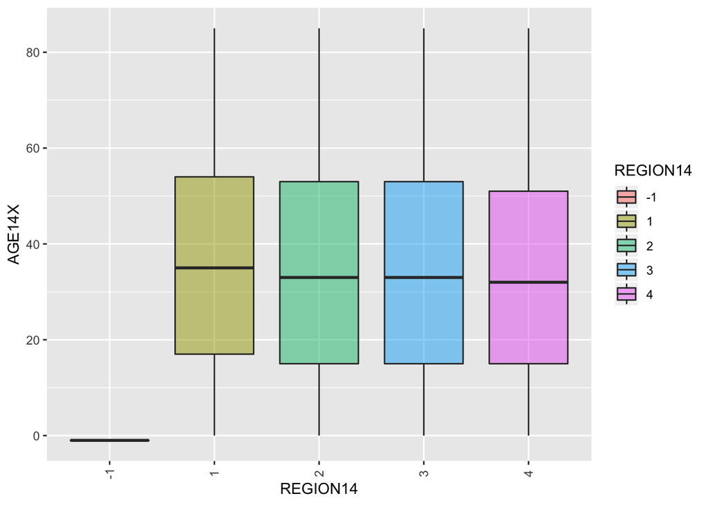

```
##
##    -1     1     2     3     4
##   209  5292  6299 13135  9940
```

Doesn’t seem to be any material differences between regions. Except for region -1, which seems to indicate missing values. This would seem to indicate some link between missing region and missing age. There is likely an admininstrative link, e.g. they come from the same survey/agency.

#### View as stacked and split histograms.

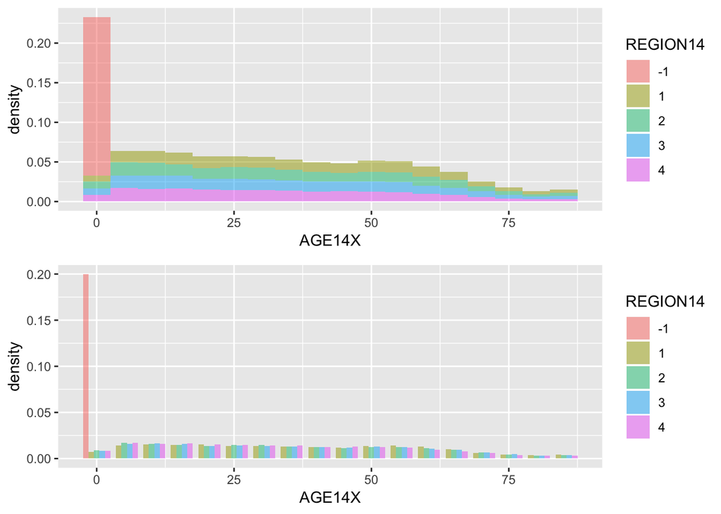

```r
#CHUNK 3
library(gridExtra) #for gridArrange

## Stacked histogram
p1 <- ggplot(data = meps.sub, aes(AGE14X, fill=REGION14, ..density..)) +
       geom_histogram(binwidth = 5, alpha = 0.5)

## Split histogram
p2 <- ggplot(data = meps.sub, aes(AGE14X, fill=REGION14, ..density..)) +
       geom_histogram(binwidth = 5, alpha = 0.5, position = "dodge")
grid.arrange(p1,p2,ncol=1)
```

Region -1 is distorting the viz. Since we’ve already surmised that it is missing data, let’s just leave out and look again.

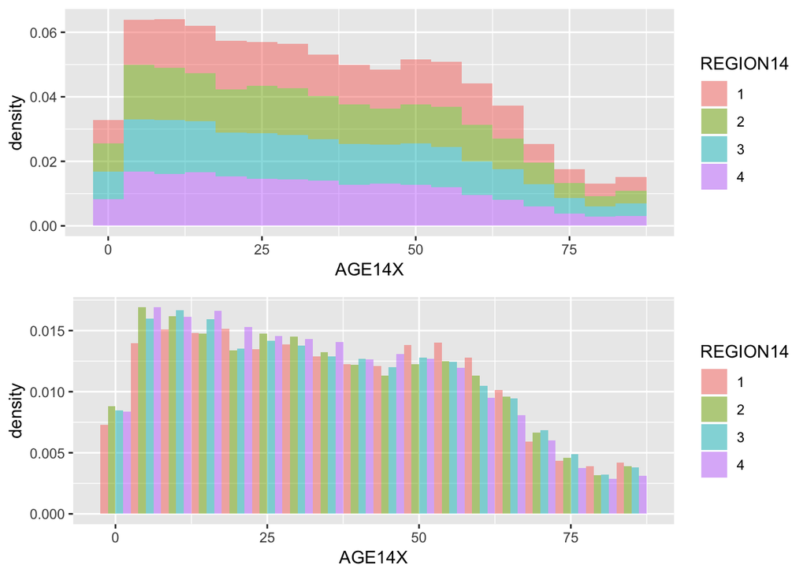

```r
#CHUNK 3b
library(gridExtra) #for gridArrange

## Stacked histogram
p1 <- ggplot(data = meps.sub[meps.sub$REGION14 != '-1',], aes(AGE14X, fill=REGION14, ..density..)) +
       geom_histogram(binwidth = 5, alpha = 0.5)

## Split histogram
p2 <- ggplot(data = meps.sub[meps.sub$REGION14 != '-1',], aes(AGE14X, fill=REGION14, ..density..)) +
       geom_histogram(binwidth = 5, alpha = 0.5, position = "dodge")
grid.arrange(p1,p2,ncol=1)
```

There appears to be a weird ‘jagged’ edge at age 0. Maybe some of those ‘missing’ values are actually age 0? Will leave that for an exploration at another time.

##### Build a stacked bar chart of region vs **SEX**.

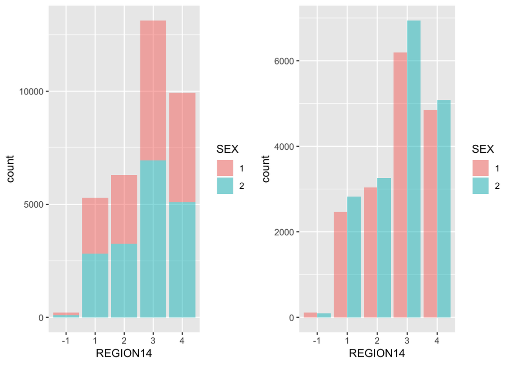

```r
p1 <- ggplot(data = meps.sub, aes(x = REGION14, fill = SEX)) +
        geom_bar(stat = "count", alpha = 0.5)
p2 <- ggplot(data = meps.sub, aes(x = REGION14, fill = SEX)) +
        geom_bar(stat = "count", alpha = 0.5, position = "dodge")
grid.arrange(p1,p2,ncol=2)
```

#### Run a heat map. For this we will explore age vs family income (FAMINC14)

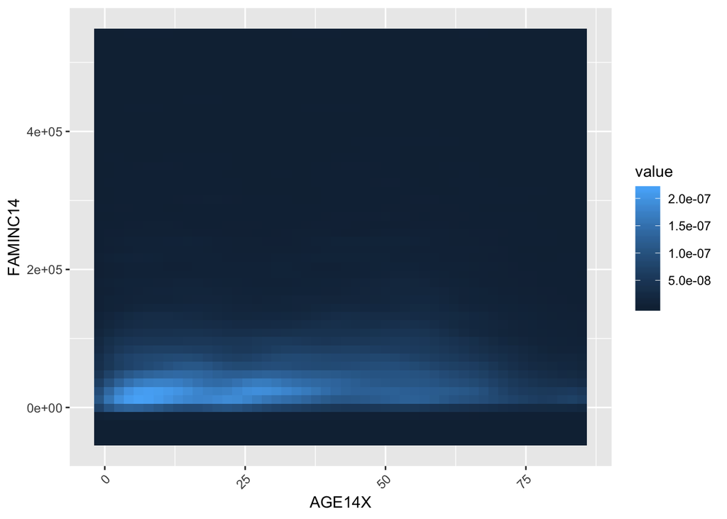

#### Scatterplot - Age vs Family Income

Instead of a heat map let’s try a scatter plot. Color by region.

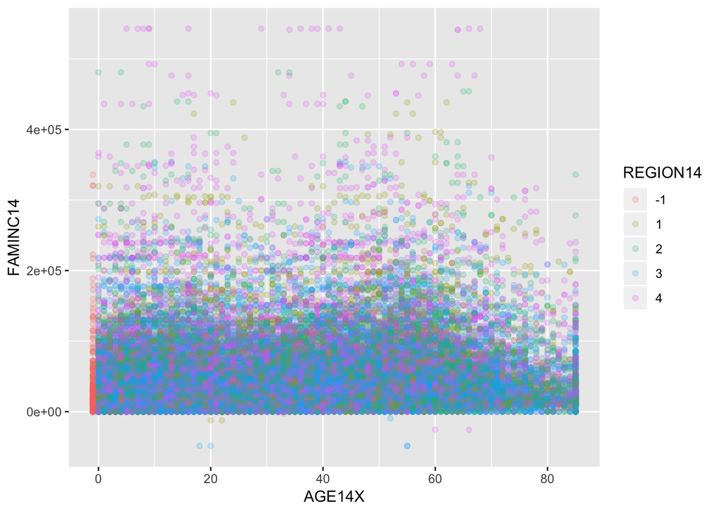

```r
#scatterplot
pid <- ggplot(data = meps.sub, aes(x = AGE14X, y = FAMINC14, color = REGION14)) +
        geom_point(alpha = 0.2)
pid
```

```r
#Save a png
ggsave("ex4_2_9_plot1.png")
```

#### Total Health care expenditures vs amount paid by private insurance.

This is a bit of a trivial example, but seems to really confirm our intuition. If you have insurance, then it likely pays for all of the expenditure. This can be seen in the 45 degree ‘V’ shape. The 45% line indicates where it’s all/most paid by private insurance, where the line parallel to the x-axis indicates where none/little is paid by private insurance.

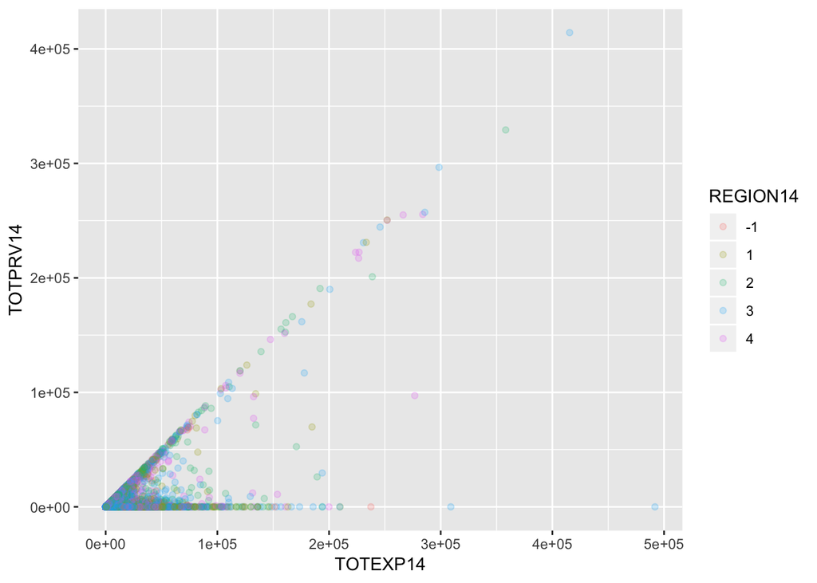

```r
pie <- ggplot(data = meps.sub, aes(x = TOTEXP14, y = TOTPRV14, color = REGION14)) +
        geom_point(alpha = 0.2)
pie
```